# Housing Market - Seattle Area

Anti-Code Group

10/5/2019

# 1 Description of the Data

## 1.1 Source Data

https://www.kaggle.com/harlfoxem/housesalesprediction/data

https://github.com/matteobucalossi50/DATS6101_Project

```
## 'data.frame':    21613 obs. of  21 variables:
##  $ id           : num  7129300520 6414100192 5631500400 2487200875 1954400510 ...
##  $ date         : Factor w/ 372 levels "20140502T000000",..: 165 221 291 221 284 11 57 252 340 306 ...
##  $ price        : num  221900 538000 180000 604000 510000 ...
##  $ bedrooms     : int  3 3 2 4 3 4 3 3 3 3 ...
##  $ bathrooms    : num  1 2.25 1 3 2 4.5 2.25 1.5 1 2.5 ...
##  $ sqft_living  : int  1180 2570 770 1960 1680 5420 1715 1060 1780 1890 ...
##  $ sqft_lot     : int  5650 7242 10000 5000 8080 101930 6819 9711 7470 6560 ...
##  $ floors       : num  1 2 1 1 1 1 2 1 1 2 ...
##  $ waterfront   : int  0 0 0 0 0 0 0 0 0 0 ...
##  $ view         : int  0 0 0 0 0 0 0 0 0 0 ...
##  $ condition    : int  3 3 3 5 3 3 3 3 3 3 ...
##  $ grade        : int  7 7 6 7 8 11 7 7 7 7 ...
##  $ sqft_above   : int  1180 2170 770 1050 1680 3890 1715 1060 1050 1890 ...
##  $ sqft_basement: int  0 400 0 910 0 1530 0 0 730 0 ...
##  $ yr_built     : int  1955 1951 1933 1965 1987 2001 1995 1963 1960 2003 ...
##  $ yr_renovated : int  0 1991 0 0 0 0 0 0 0 0 ...
##  $ zipcode      : int  98178 98125 98028 98136 98074 98053 98003 98198 98146 98038 ...
##  $ lat          : num  47.5 47.7 47.7 47.5 47.6 ...
##  $ long         : num  -122 -122 -122 -122 -122 ...
##  $ sqft_living15: int  1340 1690 2720 1360 1800 4760 2238 1650 1780 2390 ...
##  $ sqft_lot15   : int  5650 7639 8062 5000 7503 101930 6819 9711 8113 7570 ...
```

```
##  [1] "id"            "date"          "price"         "bedrooms"
##  [5] "bathrooms"     "sqft_living"   "sqft_lot"      "floors"
##  [9] "waterfront"    "view"          "condition"     "grade"
## [13] "sqft_above"    "sqft_basement" "yr_built"      "yr_renovated"
## [17] "zipcode"       "lat"           "long"          "sqft_living15"
## [21] "sqft_lot15"
```

## 1.2 Summary for Price

```
##    Min. 1st Qu.  Median    Mean 3rd Qu.    Max.
##   78000  322000  450000  540198  645000 7700000
```

```
## [1] 540198.3
```

```
## [1] 367141.6
```

```
## [1] 134792956735
```

## 1.3 Geographic Coverage of Data

Below is a visualization of the points in the dataset by price, plotted with the leaflet library. Note that the data have been divided by quantiles to provide a better understanding of the distribution of rental price.

[interactive chart not shown]

# 2 Exploratory Data Analysis

## 2.1 Distribution of Price

The following are housing price distributions (histograms). The first includes the frequency of all price occurences, and the other only shows those less than or equal to $2M (the vast majority of data points are below this price point). Also included is a Q-Q plot showing the distribution of the data.

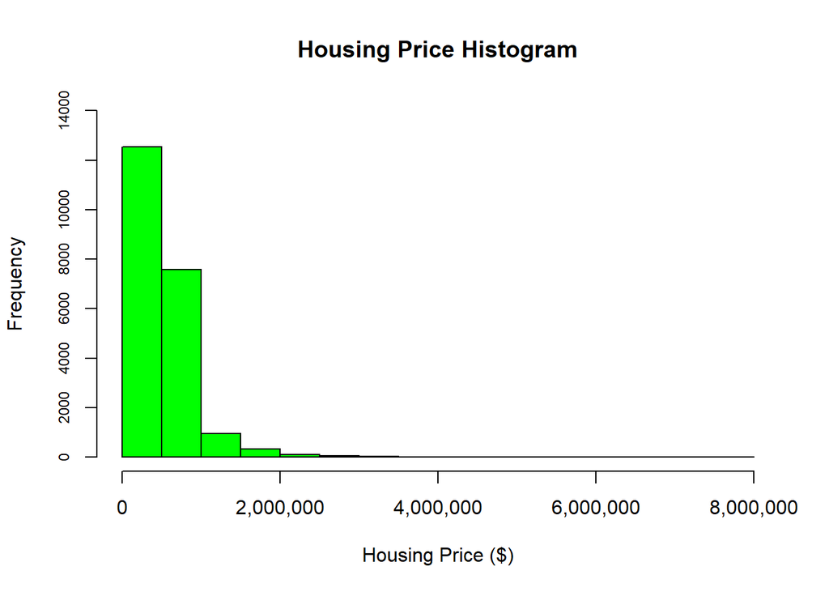

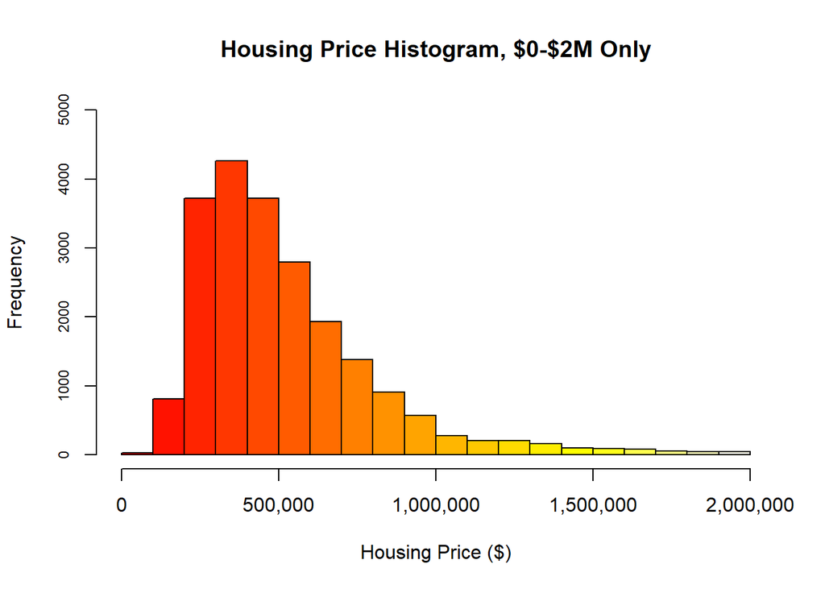

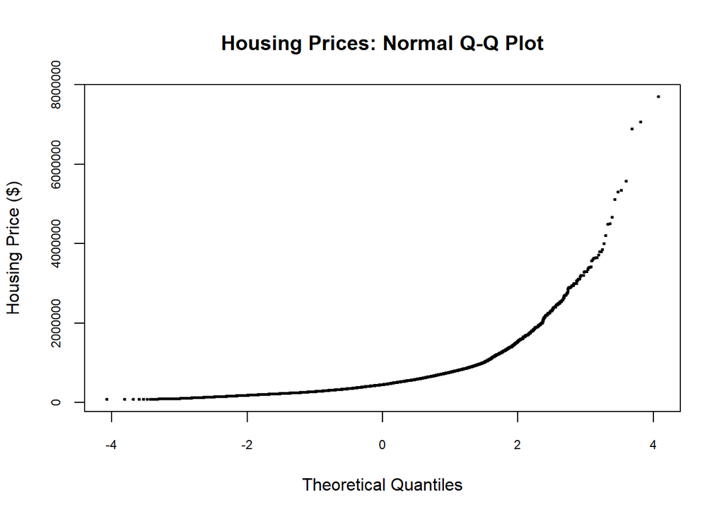

##The following is a summary of price per square foot, per annum.

```
## # A tibble: 2 x 5
##   date       price sqft_living  sqft_lot price_per_sqft
##   <fct>      <dbl>       <int>     <int>          <dbl>
## 1 2014  7884309242    30685855 218423994           257.
## 2 2015  3781813216    14241236 107671937           266.
```

## 2.2 High observations

The following are a summary of the first few rows for bedrooms, land area, and living space (price showed is average for that variable level (e.g. $262,000 is the average price for grade 3 construction).

Top 5 rows of prices across our variable set.

```
##           id            date   price bedrooms bathrooms sqft_living
## 1 8907500070 20150413T000000 5350000        5      5.00        8000
## 2 9808700762 20140611T000000 7062500        5      4.50       10040
## 3 2470100110 20140804T000000 5570000        5      5.75        9200
## 4 6762700020 20141013T000000 7700000        6      8.00       12050
## 5 9208900037 20140919T000000 6885000        6      7.75        9890
##   sqft_lot floors condition grade sqft_above sqft_basement yr_built
## 1    23985    2.0         3    12       6720          1280     2009
## 2    37325    2.0         3    11       7680          2360     1940
## 3    35069    2.0         3    13       6200          3000     2001
## 4    27600    2.5         4    13       8570          3480     1910
## 5    31374    2.0         3    13       8860          1030     2001
##   yr_renovated zipcode     lat     long sqft_living15 sqft_lot15
## 1            0   98004 47.6232 -122.220          4600      21750
## 2         2001   98004 47.6500 -122.214          3930      25449
## 3            0   98039 47.6289 -122.233          3560      24345
## 4         1987   98102 47.6298 -122.323          3940       8800
## 5            0   98039 47.6305 -122.240          4540      42730
```

```
##           id            date   price bedrooms bathrooms sqft_living
## 1 6762700020 20141013T000000 7700000        6      8.00       12050
## 2 9808700762 20140611T000000 7062500        5      4.50       10040
## 3 9208900037 20140919T000000 6885000        6      7.75        9890
## 4 2470100110 20140804T000000 5570000        5      5.75        9200
## 5 8907500070 20150413T000000 5350000        5      5.00        8000
##   sqft_lot floors condition grade sqft_above sqft_basement yr_built
## 1    27600    2.5         4    13       8570          3480     1910
## 2    37325    2.0         3    11       7680          2360     1940
## 3    31374    2.0         3    13       8860          1030     2001
## 4    35069    2.0         3    13       6200          3000     2001
## 5    23985    2.0         3    12       6720          1280     2009
##   yr_renovated zipcode     lat     long sqft_living15 sqft_lot15
## 1         1987   98102 47.6298 -122.323          3940       8800
## 2         2001   98004 47.6500 -122.214          3930      25449
## 3            0   98039 47.6305 -122.240          4540      42730
## 4            0   98039 47.6289 -122.233          3560      24345
## 5            0   98004 47.6232 -122.220          4600      21750
```

Top 5 rows of sqft. living across our variable set.

```
##           id            date   price bedrooms bathrooms sqft_living
## 1 9808700762 20140611T000000 7062500        5      4.50       10040
## 2 6762700020 20141013T000000 7700000        6      8.00       12050
## 3 1924059029 20140617T000000 4668000        5      6.75        9640
## 4 9208900037 20140919T000000 6885000        6      7.75        9890
## 5 1225069038 20140505T000000 2280000        7      8.00       13540
##   sqft_lot floors condition grade sqft_above sqft_basement yr_built
## 1    37325    2.0         3    11       7680          2360     1940
## 2    27600    2.5         4    13       8570          3480     1910
## 3    13068    1.0         3    12       4820          4820     1983
## 4    31374    2.0         3    13       8860          1030     2001
## 5   307752    3.0         3    12       9410          4130     1999
##   yr_renovated zipcode     lat     long sqft_living15 sqft_lot15
## 1         2001   98004 47.6500 -122.214          3930      25449
## 2         1987   98102 47.6298 -122.323          3940       8800
## 3         2009   98040 47.5570 -122.210          3270      10454
## 4            0   98039 47.6305 -122.240          4540      42730
## 5            0   98053 47.6675 -121.986          4850     217800
```

```
##           id            date   price bedrooms bathrooms sqft_living
## 1 1225069038 20140505T000000 2280000        7      8.00       13540
## 2 6762700020 20141013T000000 7700000        6      8.00       12050
## 3 9808700762 20140611T000000 7062500        5      4.50       10040
## 4 9208900037 20140919T000000 6885000        6      7.75        9890
## 5 1924059029 20140617T000000 4668000        5      6.75        9640
##   sqft_lot floors condition grade sqft_above sqft_basement yr_built
## 1   307752    3.0         3    12       9410          4130     1999
## 2    27600    2.5         4    13       8570          3480     1910
## 3    37325    2.0         3    11       7680          2360     1940
## 4    31374    2.0         3    13       8860          1030     2001
## 5    13068    1.0         3    12       4820          4820     1983
##   yr_renovated zipcode     lat     long sqft_living15 sqft_lot15
## 1            0   98053 47.6675 -121.986          4850     217800
## 2         1987   98102 47.6298 -122.323          3940       8800
## 3         2001   98004 47.6500 -122.214          3930      25449
## 4            0   98039 47.6305 -122.240          4540      42730
## 5         2009   98040 47.5570 -122.210          3270      10454
```

Top 5 rows of land area across our variable set.

```
##           id            date  price bedrooms bathrooms sqft_living
## 1 1020069017 20150327T000000 700000        4      1.00        1300
## 2  722069232 20140905T000000 998000        4      3.25        3770
## 3 2623069031 20140521T000000 542500        5      3.25        3010
## 4 2323089009 20150119T000000 855000        4      3.50        4030
## 5 3326079016 20150504T000000 190000        2      1.00         710
##   sqft_lot floors condition grade sqft_above sqft_basement yr_built
## 1  1651359    1.0         4     6       1300             0     1920
## 2   982998    2.0         3    10       3770             0     1992
## 3  1074218    1.5         5     8       2010          1000     1931
## 4  1024068    2.0         3    10       4030             0     2006
## 5  1164794    1.0         2     5        710             0     1915
##   yr_renovated zipcode     lat     long sqft_living15 sqft_lot15
## 1            0   98022 47.2313 -122.023          2560     425581
## 2            0   98058 47.4140 -122.087          2290      37141
## 3            0   98027 47.4564 -122.004          2450      68825
## 4            0   98045 47.4619 -121.744          1830      11700
## 5            0   98014 47.6888 -121.909          1680      16730
```

```
##           id            date  price bedrooms bathrooms sqft_living
## 1 1020069017 20150327T000000 700000        4      1.00        1300
## 2 3326079016 20150504T000000 190000        2      1.00         710
## 3 2623069031 20140521T000000 542500        5      3.25        3010
## 4 2323089009 20150119T000000 855000        4      3.50        4030
## 5  722069232 20140905T000000 998000        4      3.25        3770
##   sqft_lot floors condition grade sqft_above sqft_basement yr_built
## 1  1651359    1.0         4     6       1300             0     1920
## 2  1164794    1.0         2     5        710             0     1915
## 3  1074218    1.5         5     8       2010          1000     1931
## 4  1024068    2.0         3    10       4030             0     2006
## 5   982998    2.0         3    10       3770             0     1992
##   yr_renovated zipcode     lat     long sqft_living15 sqft_lot15
## 1            0   98022 47.2313 -122.023          2560     425581
## 2            0   98014 47.6888 -121.909          1680      16730
## 3            0   98027 47.4564 -122.004          2450      68825
## 4            0   98045 47.4619 -121.744          1830      11700
## 5            0   98058 47.4140 -122.087          2290      37141
```

Top 4 rows of bedroom #’s across our variable set.

```
##           id            date   price bedrooms bathrooms sqft_living
## 1 1773100755 20140821T000000  520000       11      3.00        3000
## 2  627300145 20140814T000000 1148000       10      5.25        4590
## 3 5566100170 20141029T000000  650000       10      2.00        3610
## 4 8812401450 20141229T000000  660000       10      3.00        2920
##   sqft_lot floors condition grade sqft_above sqft_basement yr_built
## 1     4960      2         3     7       2400           600     1918
## 2    10920      1         3     9       2500          2090     2008
## 3    11914      2         4     7       3010           600     1958
## 4     3745      2         4     7       1860          1060     1913
##   yr_renovated zipcode     lat     long sqft_living15 sqft_lot15
## 1         1999   98106 47.5560 -122.363          1420       4960
## 2            0   98004 47.5861 -122.113          2730      10400
## 3            0   98006 47.5705 -122.175          2040      11914
## 4            0   98105 47.6635 -122.320          1810       3745
```

```
##           id            date   price bedrooms bathrooms sqft_living
## 1 1773100755 20140821T000000  520000       11      3.00        3000
## 2  627300145 20140814T000000 1148000       10      5.25        4590
## 3 5566100170 20141029T000000  650000       10      2.00        3610
## 4 8812401450 20141229T000000  660000       10      3.00        2920
##   sqft_lot floors condition grade sqft_above sqft_basement yr_built
## 1     4960      2         3     7       2400           600     1918
## 2    10920      1         3     9       2500          2090     2008
## 3    11914      2         4     7       3010           600     1958
## 4     3745      2         4     7       1860          1060     1913
##   yr_renovated zipcode     lat     long sqft_living15 sqft_lot15
## 1         1999   98106 47.5560 -122.363          1420       4960
## 2            0   98004 47.5861 -122.113          2730      10400
## 3            0   98006 47.5705 -122.175          2040      11914
## 4            0   98105 47.6635 -122.320          1810       3745
```

Mean prices for each condition level.

```
##   condition    price
## 1         1 341067.2
## 2         2 328149.3
## 3         3 542089.2
## 4         4 521274.1
## 5         5 612401.9
```

Mean prices for each grade level.

```
##    grade     price
## 1      3  262000.0
## 2      4  212001.9
## 3      5  248524.0
## 4      6  301919.6
## 5      7  402565.6
## 6      8  542944.0
## 7      9  773513.2
## 8     10 1071771.1
## 9     11 1496841.7
## 10    12 2201284.6
## 11    13 3709615.4
```

Below is a scatterplot of price vs. living space, along with their correlation.

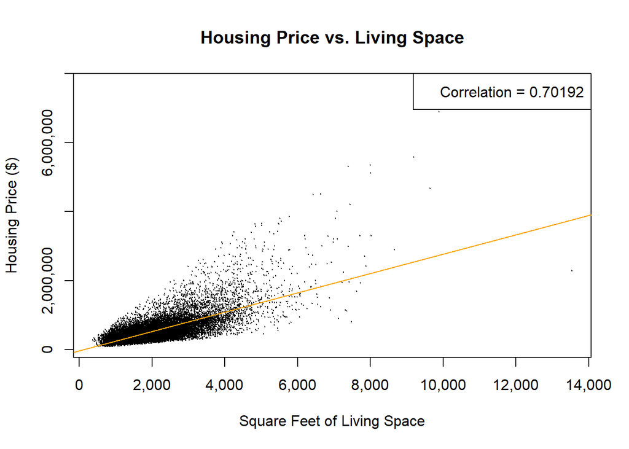

## 2.3 Boxplot & Scatterplot for Living Space

Below are a boxplot and scatterplot for living space vs. price.

```
## [1] 13540
```

```
## [1] 370
```

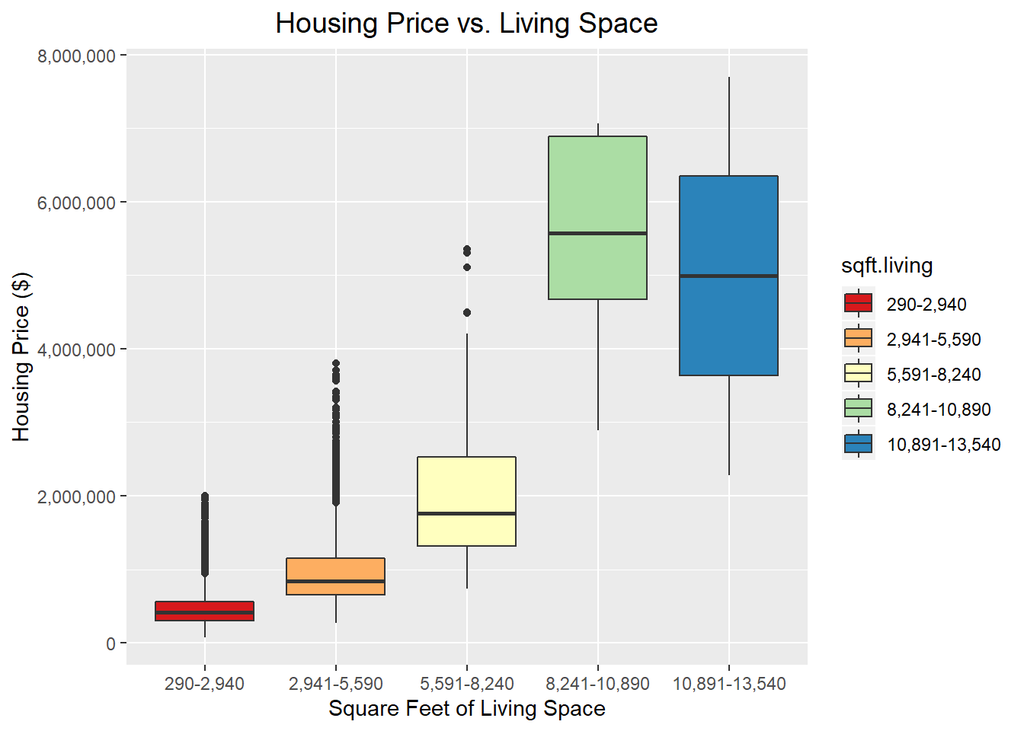

## 2.4 Comparison price and lot sqft

The following includes histograms of lot square feet (including one equal to or below 25,000 sqft., where the vast majority of data points lie). Also included is a scatterplot showing the correlation between price and land area.

```
##    Min. 1st Qu.  Median    Mean 3rd Qu.    Max.
##     520    5040    7619   15100   10686 1651359
```

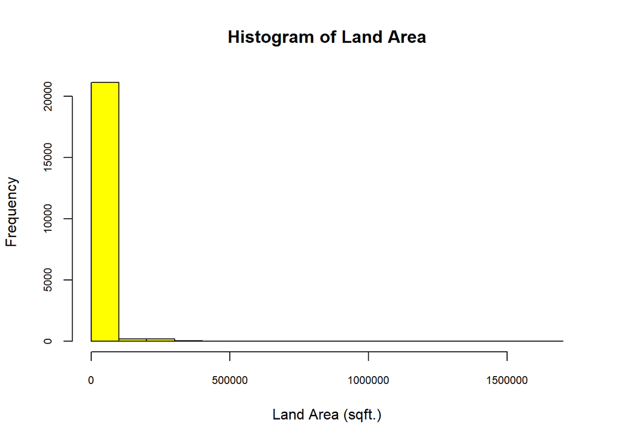

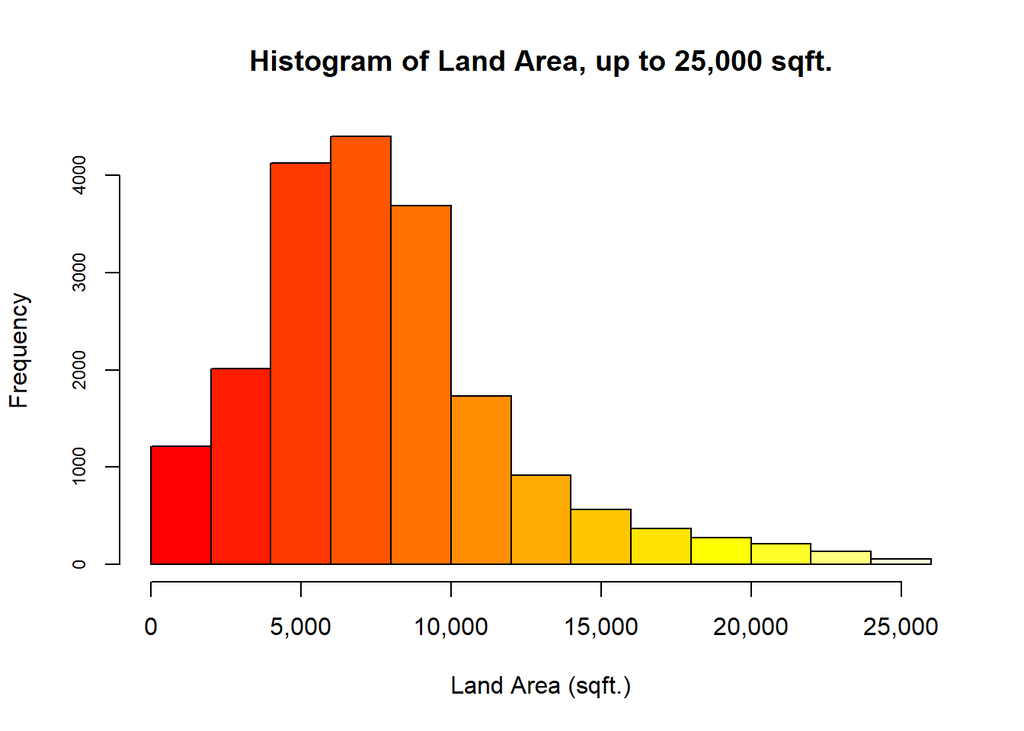

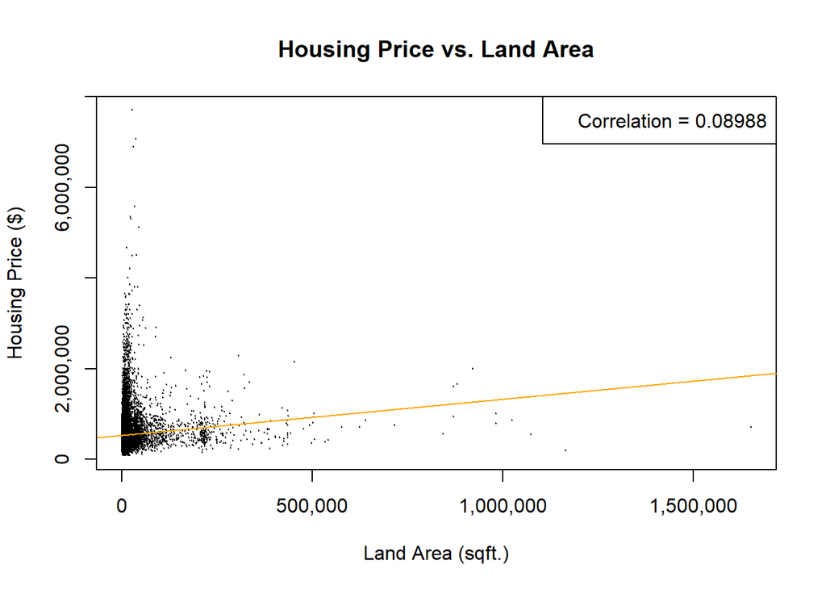

## 2.5 Comparison of Land Area and Housing Price

Included below is a boxplot of land area vs. housing price.

```
## [1] 1651359
```

```
## [1] 520
```

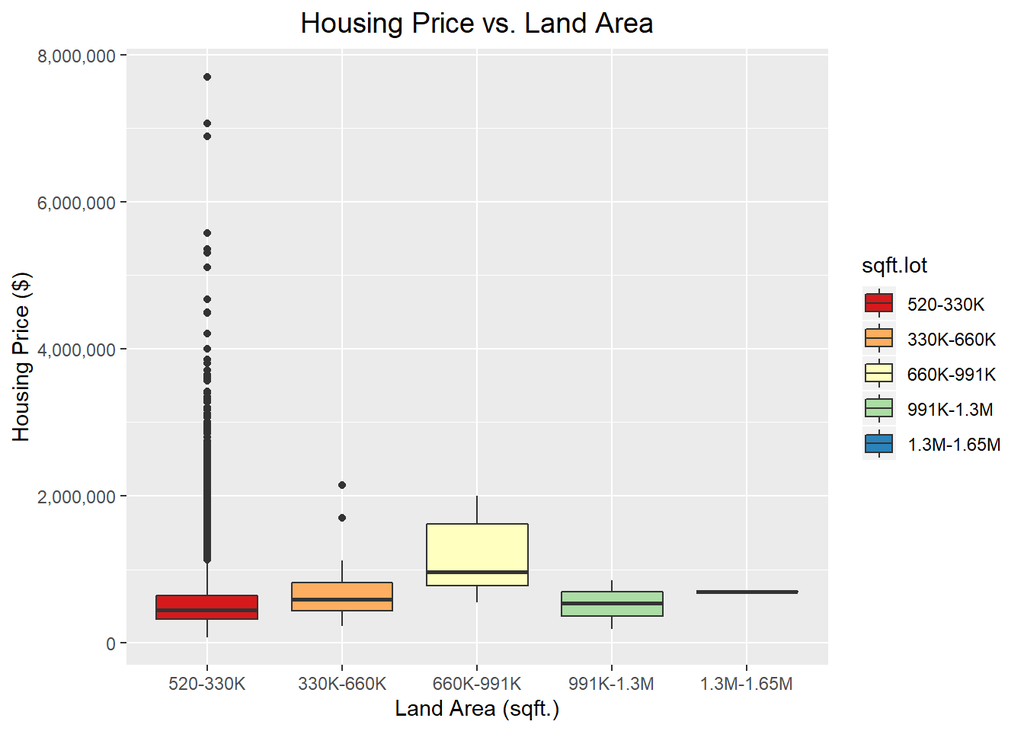

Included below is a boxplot of price vs. land area (log version). Log versions are used throughout as a better way to visualize our boxplots (better method than removing outliers).

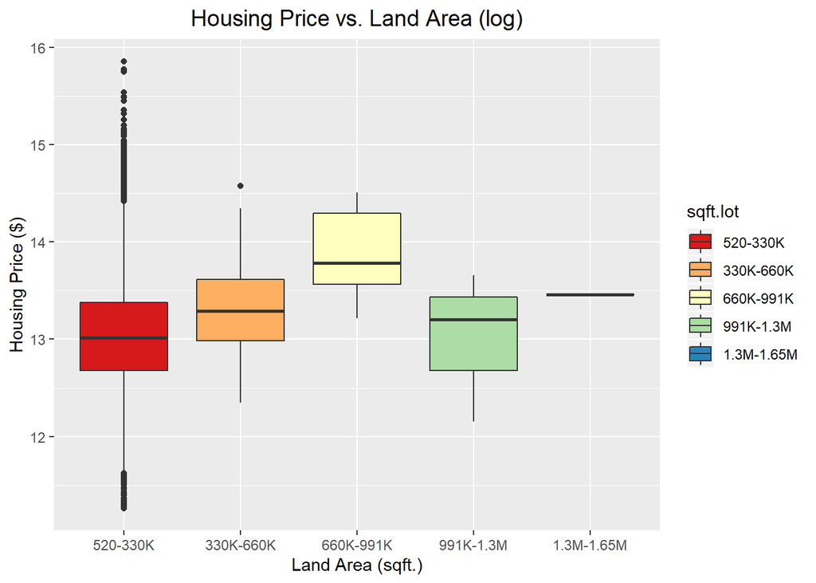

## 2.6 Comparison of price and condition

Boxplots of price vs. apartment condition (regular and log versions).

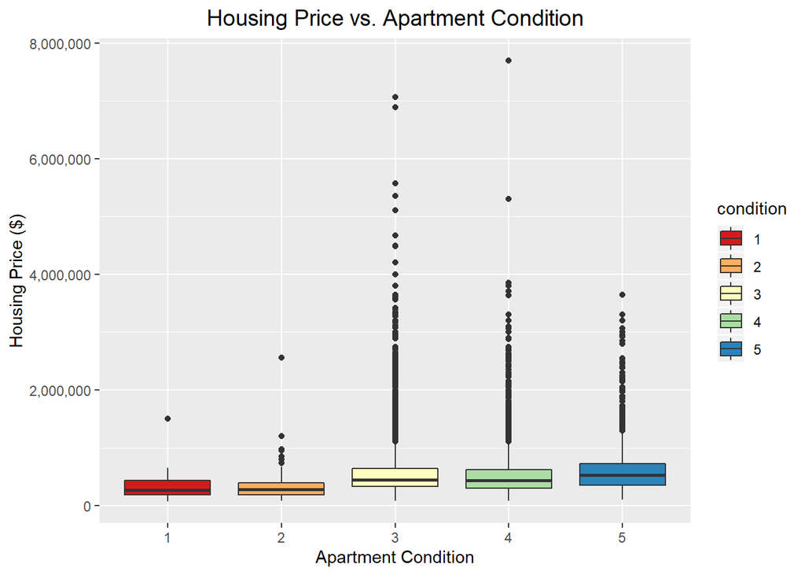

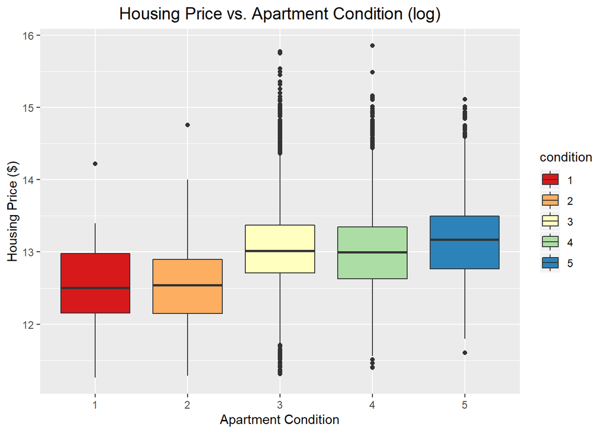

## 2.7 Comparison of price and grade (construction and design)

Boxplots of price and grade (regular and log versions).

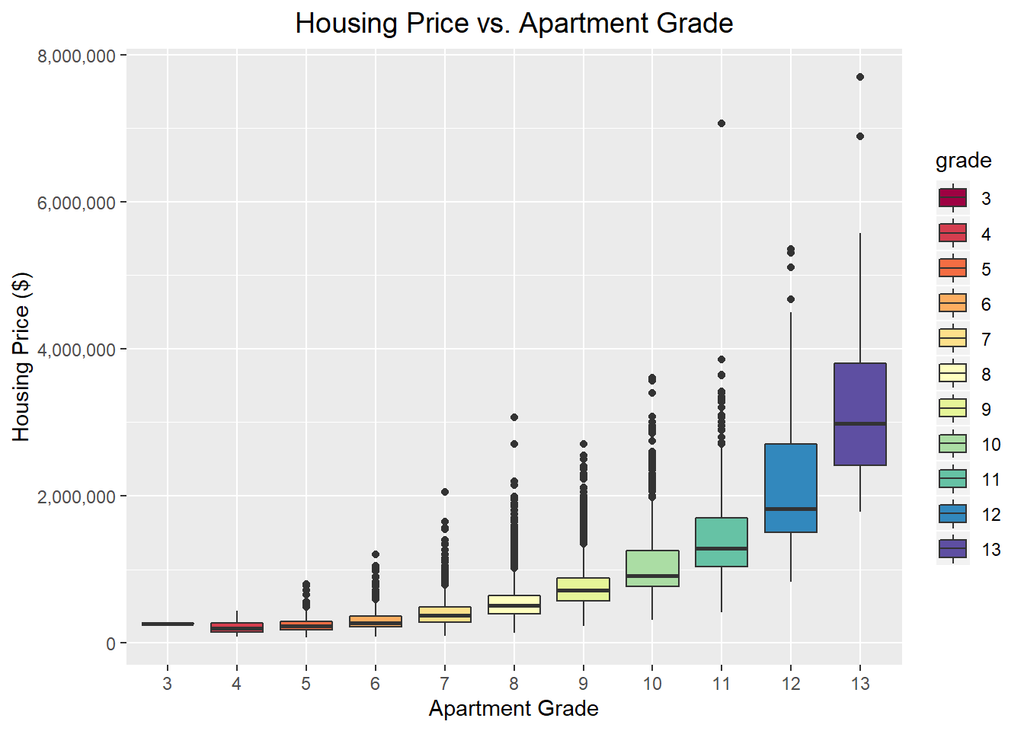

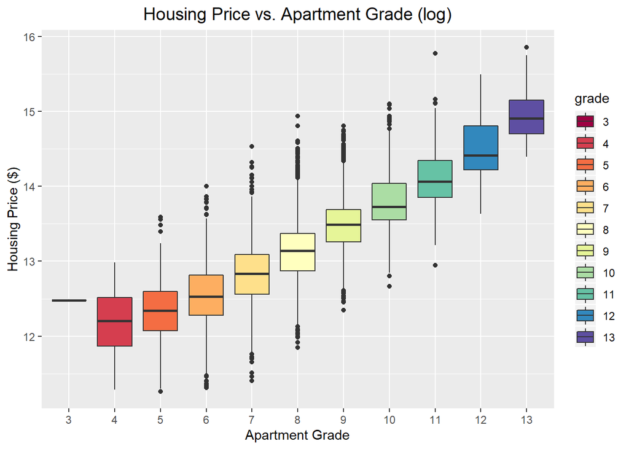

## 2.8 Comparison of price and # bedrooms

Boxplot of housing price vs. number of bedrooms (log version).

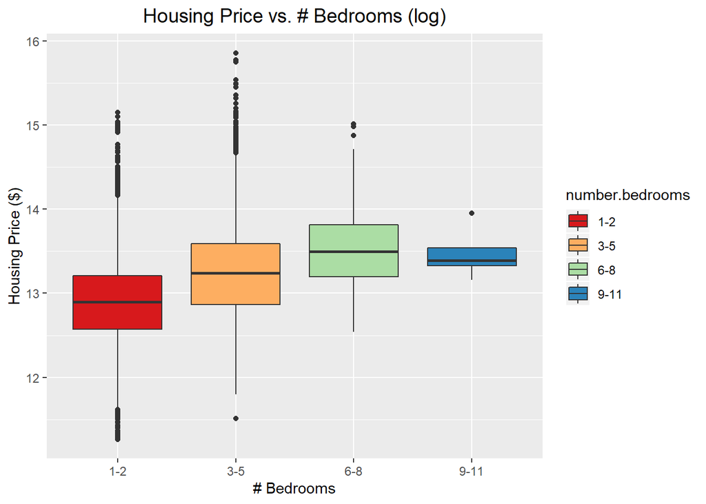

## 2.9 Comparison of price and year built

Histogram and boxplot of price vs. year built (log version).

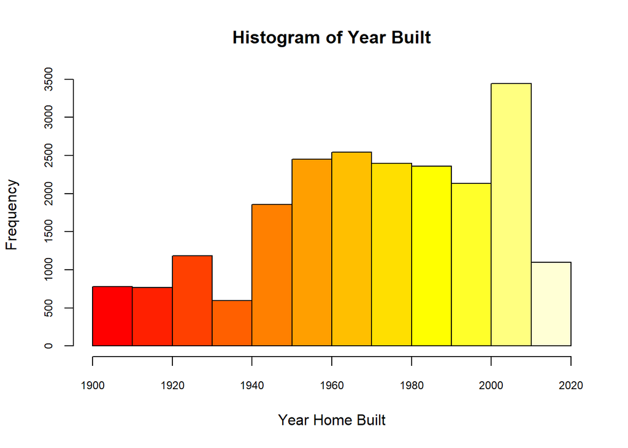

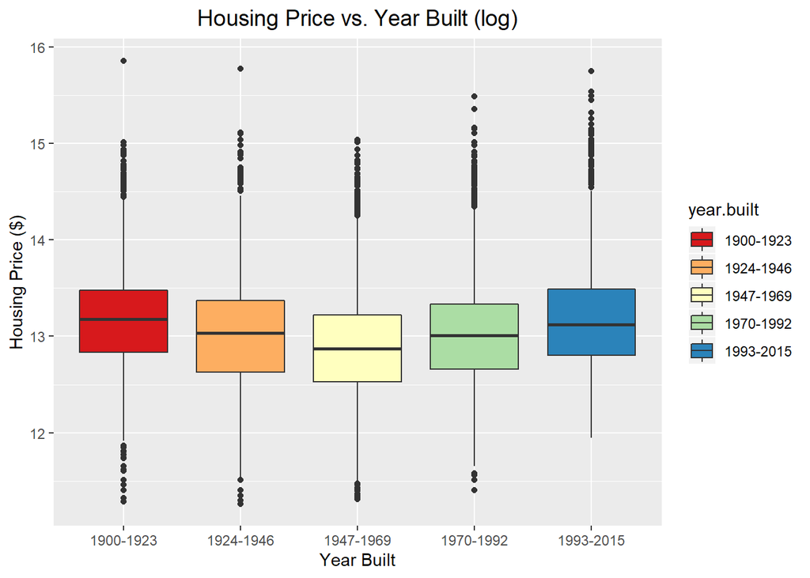

# 3 Hypothesis Testing

## 3.1 Chi-square tests

### 3.1.1 Chi-square of the condition variable. Significant relationship with price.

H0: The condition and grade are independent. H1: The condition and grade are not independent.

```
##
##  Pearson's Chi-squared test
##
## data:  cond.tbl
## X-squared = 1456.5, df = 40, p-value < 0.00000000000000022
```

Since p-value is lower 0.05, we need to reject the null hypothesis. Thus, the condition and grade are not independent. They are corrlated.

### 3.1.2 Chi-square of the “year built” variable. Significant relationship with price.

H0: The year built and grade are independent. H1: The year built and grade are not independent.

```
##
##  Pearson's Chi-squared test
##
## data:  grade.tbl
## X-squared = 6403.9, df = 40, p-value < 0.00000000000000022
```

Since p-value is lower 0.05, we need to reject the null hypothesis. Thus, the year built and grade are not independent. They are corrlated.

### 3.1.3 Chi-square of the bedroom and bathroom variables. Significant relationship with price.

```
##
##  Pearson's Chi-squared test
##
## data:  bed_p
## X-squared = 2287.1, df = 21, p-value < 0.00000000000000022
```

```
##
##  Pearson's Chi-squared test
##
## data:  bath_p
## X-squared = 4534.4, df = 21, p-value < 0.00000000000000022
```

Since both p-values are lower 0.05, we need to reject the null hypothesis. Thus, the number of bedrooms and the number of bathrooms are not independent from the grade of house. They are corrlated. Generally, the price increases when the number of bedrooms and bathrooms become greater.

## 3.2 Anova tests

Below are ANOVA tests on land area, combined with BP tests and post-hoc Tukey tests.

### 3.2.1 ANOVA, BP, and Tukey tests on land area variable.

BP test:  
H0: The variances of prices are the same accross the different sqft of lot levels.  
H1: The variances of prices are different accross the different sqft of lot levels.

ANOVA test:  
H0: There are no differences between the mean prices of the different sqft.lot levels.  
H1: The mean prices of the different sqft.lot levels are different.

```
##
##  studentized Breusch-Pagan test
##
## data:  kc_house_data$price ~ sqft.lot
## BP = 0.18327, df = 4, p-value = 0.996
```

```
##                Df           Sum Sq      Mean Sq F value     Pr(>F)
## sqft.lot        4    3896930121642 974232530411   7.236 0.00000809 ***
## Residuals   21591 2906956970577216 134637440164
## ---
## Signif. codes:  0 '***' 0.001 '**' 0.01 '*' 0.05 '.' 0.1 ' ' 1
```

```
##   Tukey multiple comparisons of means
##     95% family-wise confidence level
##
## Fit: aov(formula = kc_house_data$price ~ sqft.lot)
##
## $sqft.lot
##                            diff         lwr       upr     p adj
## 330K-660K-520-330K    130987.12   -15180.91  277155.1 0.1036807
## 660K-991K-520-330K    619509.73   265542.06  973477.4 0.0000178
## 991K-1.3M-520-330K    -10511.11  -588470.82  567448.6 0.9999986
## 1.3M-1.65M-520-330K   160322.23  -840686.88 1161331.3 0.9924421
## 660K-991K-330K-660K   488522.61   105684.32  871360.9 0.0045550
## 991K-1.3M-330K-660K  -141498.23  -737576.64  454580.2 0.9671378
## 1.3M-1.65M-330K-660K   29335.11  -982243.50 1040913.7 0.9999912
## 991K-1.3M-660K-991K  -630020.83 -1307691.47   47649.8 0.0828052
## 1.3M-1.65M-660K-991K -459187.50 -1520893.34  602518.3 0.7629901
## 1.3M-1.65M-991K-1.3M  170833.33  -985005.59 1326672.3 0.9944467
```

Note that the p-value of BP test are 0.996, which is greater than 0.05. Thus, the variances are the same for different groups. Then we use ANOVA test analysis the differences of mean prices. Since the p-value is lower than 0.05, we need to reject the null hypothesis. The mean prices of the different sqft.lot levels are different. From the Turkey test we can see, the p-value of the 660k-991k and 520k-330k, 660k-991k and 330K-660K, 660k-991k and 991K-1.3M are the lowest three. And the p-value for other pairs are very high, which means the means price of 660k-991k(the median level) are higher than others’. Thus the land area of 660k-991k are the most popular level for houses in WA.

### 3.2.2 ANOVA, BP, and Tukey tests on condition variable.

BP test:  
H0: The variances of prices are the same accross different condition.  
H1: The variances of prices are different accross different condition.

ANOVA test:  
H0: There are no differences between the mean prices of the different condition.  
H1: The mean prices of the different condition are different.

```
##
##  studentized Breusch-Pagan test
##
## data:  price ~ condition
## BP = 4.9518, df = 4, p-value = 0.2923
```

```
##                            Df           Sum Sq       Mean Sq F value
## kc_house_data$condition     4   19739857713567 4934964428392   36.85
## Residuals               21591 2891114042985296  133903665554
##                                      Pr(>F)
## kc_house_data$condition <0.0000000000000002 ***
## Residuals
## ---
## Signif. codes:  0 '***' 0.001 '**' 0.01 '*' 0.05 '.' 0.1 ' ' 1
```

```
##   Tukey multiple comparisons of means
##     95% family-wise confidence level
##
## Fit: aov(formula = kc_house_data$price ~ kc_house_data$condition)
##
## $`kc_house_data$condition`
##          diff         lwr        upr     p adj
## 2-1 -12917.89 -213477.901 187642.112 0.9997871
## 3-1 201021.91   15459.092 386584.726 0.0259837
## 4-1 180206.86   -5637.206 366050.923 0.0624965
## 5-1 271334.62   84389.004 458280.243 0.0007186
## 3-2 213939.80  136914.399 290965.207 0.0000000
## 4-2 193124.75  115424.238 270825.268 0.0000000
## 5-2 284252.52  203952.963 364552.073 0.0000000
## 4-3 -20815.05  -36518.962  -5111.138 0.0027748
## 5-3  70312.71   44675.605  95949.824 0.0000000
## 5-4  91127.76   63528.517 118727.012 0.0000000
```

### 3.2.3 ANOVA, BP, and Tukey tests on the living space variable.

H0: The variances of prices are the same accross the different sqft of living levels.  
H1: The variances of prices are different accross the different sqft of living levels.

```
##
##  studentized Breusch-Pagan test
##
## data:  kc_house_data$price ~ sqft.living
## BP = 3179.5, df = 4, p-value < 0.00000000000000022
```

Since the p-value is lower than 0.05, we need to reject the null hypothesis. The variances for different sqft of living levels are different. Thus, the ANOVA test is not applicable.

### 3.2.4 ANOVA, BP, and Tukey tests on “year built” variable.

H0: The variances of prices are the same accross the different year of built.  
H1: The variances of prices are different accross the different year of built.

```
##
##  studentized Breusch-Pagan test
##
## data:  kc_house_data$price ~ year.built
## BP = 40.918, df = 4, p-value = 0.00000002795
```

Since the p-value is lower than 0.05, we need to reject the null hypothesis. The variances for different year built groups are different. Thus, the ANOVA test is not applicable.

### 3.2.5 ANOVA, BP, and Tukey tests on “construction grade” variable.

H0: The variances of prices are the same accross the different grade.  
H1: The variances of prices are different accross the different grade.

```
##
##  studentized Breusch-Pagan test
##
## data:  price ~ grade
## BP = 2645.6, df = 10, p-value < 0.00000000000000022
```

Since the p-value is lower than 0.05, we need to reject the null hypothesis. The variances for different grades are different. Thus, the ANOVA test is not applicable.

### 3.2.6 ANOVA, BP, and Tukey tests on “number of bedrooms” variable.

H0: The variances of prices are the same accross the different number of bedrooms groups.  
H1: The variances of prices are different accross the different number of bedrooms groups.

```
##
##  studentized Breusch-Pagan test
##
## data:  kc_house_data$price ~ number.bedrooms
## BP = 201.91, df = 3, p-value < 0.00000000000000022
```

Since the p-value is lower than 0.05, we need to reject the null hypothesis. The variances for different number of bedrooms groups are different. Thus, the ANOVA test is not applicable.

# 4 LSRL

##Model building

Below is our regression model, along with a comprehensive correlation plot.

##First, take a look at all numeric variables and their correlation.

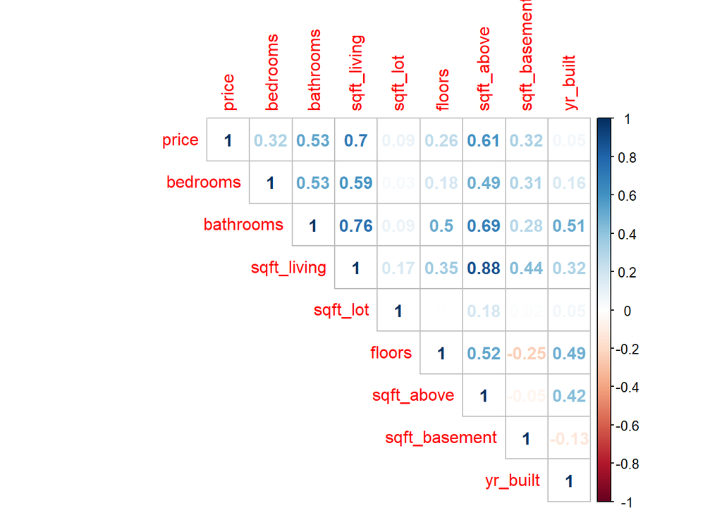

##yr_built and sqft_lot seem unrelated to price as their correlation coefficient is almost 0 so I do not chose them as dependent variables to predict the house price.

```
##
## Call:
## lm(formula = price ~ . - sqft_lot - yr_built, data = h2)
##
## Residuals:
##      Min       1Q   Median       3Q      Max
## -1706400  -142615   -21697   101727  4133425
##
## Coefficients: (1 not defined because of singularities)
##                 Estimate Std. Error t value             Pr(>|t|)
## (Intercept)    80549.196   7851.173  10.260 < 0.0000000000000002 ***
## bedrooms      -64528.790   2446.396 -26.377 < 0.0000000000000002 ***
## bathrooms       5499.452   3852.169   1.428             0.153414
## sqft_living      340.680      4.985  68.335 < 0.0000000000000002 ***
## floors         14875.018   4299.428   3.460             0.000542 ***
## sqft_above       -36.544      5.034  -7.259    0.000000000000403 ***
## sqft_basement         NA         NA      NA                   NA
## ---
## Signif. codes:  0 '***' 0.001 '**' 0.01 '*' 0.05 '.' 0.1 ' ' 1
##
## Residual standard error: 257100 on 21590 degrees of freedom
## Multiple R-squared:  0.5096, Adjusted R-squared:  0.5095
## F-statistic:  4487 on 5 and 21590 DF,  p-value: < 0.00000000000000022
```

##The coefficient of sqft_basement is NA, which indicates it has a problem with the other variables, so we dropped this one. And the p-value is bathroom is too large as unsignificant so we dropped this one as well.

```
##
## Call:
## lm(formula = price ~ . - sqft_lot - yr_built - sqft_basement -
##     bathrooms, data = h2)
##
## Residuals:
##      Min       1Q   Median       3Q      Max
## -1711175  -142619   -21684   101736  4134675
##
## Coefficients:
##               Estimate Std. Error t value             Pr(>|t|)
## (Intercept)  81162.156   7839.612  10.353 < 0.0000000000000002 ***
## bedrooms    -63928.531   2410.051 -26.526 < 0.0000000000000002 ***
## sqft_living    343.984      4.416  77.895 < 0.0000000000000002 ***
## floors       17336.104   3938.780   4.401   0.0000108075783288 ***
## sqft_above     -37.411      4.998  -7.486   0.0000000000000738 ***
## ---
## Signif. codes:  0 '***' 0.001 '**' 0.01 '*' 0.05 '.' 0.1 ' ' 1
##
## Residual standard error: 257100 on 21591 degrees of freedom
## Multiple R-squared:  0.5095, Adjusted R-squared:  0.5094
## F-statistic:  5608 on 4 and 21591 DF,  p-value: < 0.00000000000000022
```

```
##    bedrooms sqft_living      floors  sqft_above
##    1.550600    5.368610    1.475724    5.588964
```

##Everything looks better now; I also checked the vif value of each variable and none of them is too large, it shows that there is no problem of multicollineraty. we then added the two factor variables into the dataset to see their effects.

```
##      price            bedrooms       sqft_living      sqft_above
##  Min.   :  78000   Min.   : 1.000   Min.   :  370   Min.   : 370
##  1st Qu.: 322000   1st Qu.: 3.000   1st Qu.: 1430   1st Qu.:1190
##  Median : 450000   Median : 3.000   Median : 1910   Median :1560
##  Mean   : 540198   Mean   : 3.372   Mean   : 2080   Mean   :1789
##  3rd Qu.: 645000   3rd Qu.: 4.000   3rd Qu.: 2550   3rd Qu.:2210
##  Max.   :7700000   Max.   :11.000   Max.   :13540   Max.   :9410
##
##      floors          grade      condition
##  Min.   :1.000   7      :8973   1:   29
##  1st Qu.:1.000   8      :6065   2:  170
##  Median :1.500   9      :2615   3:14020
##  Mean   :1.494   6      :2038   4: 5677
##  3rd Qu.:2.000   10     :1134   5: 1700
##  Max.   :3.500   11     : 399
##                  (Other): 372
```

```
##
## Call:
## lm(formula = price ~ ., data = h3)
##
## Residuals:
##      Min       1Q   Median       3Q      Max
## -1571904  -122108   -22410    88448  4645573
##
## Coefficients:
##                Estimate  Std. Error t value             Pr(>|t|)
## (Intercept)  119945.020  235012.196   0.510             0.609792
## bedrooms     -27981.047    2255.576 -12.405 < 0.0000000000000002 ***
## sqft_living     229.897       4.366  52.655 < 0.0000000000000002 ***
## sqft_above      -89.747       4.653 -19.290 < 0.0000000000000002 ***
## floors        25574.692    3798.022   6.734       0.000000000017 ***
## grade4        52746.967  235247.781   0.224             0.822589
## grade5        47680.718  231471.191   0.206             0.836801
## grade6        77263.777  231054.845   0.334             0.738084
## grade7       110396.499  231036.907   0.478             0.632776
## grade8       183631.537  231071.918   0.795             0.426800
## grade9       327826.559  231145.293   1.418             0.156126
## grade10      530666.160  231258.193   2.295             0.021760 *
## grade11      829031.749  231551.459   3.580             0.000344 ***
## grade12     1357863.557  232717.337   5.835       0.000000005462 ***
## grade13     2552196.470  240535.179  10.610 < 0.0000000000000002 ***
## condition2   -60791.745   46520.272  -1.307             0.191301
## condition3   -62199.900   43243.711  -1.438             0.150347
## condition4    -5587.434   43281.726  -0.129             0.897284
## condition5    71583.515   43532.930   1.644             0.100118
## ---
## Signif. codes:  0 '***' 0.001 '**' 0.01 '*' 0.05 '.' 0.1 ' ' 1
##
## Residual standard error: 230900 on 21577 degrees of freedom
## Multiple R-squared:  0.6048, Adjusted R-squared:  0.6044
## F-statistic:  1834 on 18 and 21577 DF,  p-value: < 0.00000000000000022
```

##The 5 levels of condition variable are all unsignificant so we can directly drop condition variable. For the grade variable, the higher grade has significant effect on price prediction. In contrast, low grade does not effect price significantly.

```
##
## Call:
## lm(formula = price ~ . - condition, data = h3)
##
## Residuals:
##      Min       1Q   Median       3Q      Max
## -1594879  -122654   -26548    89616  4612348
##
## Coefficients:
##                Estimate  Std. Error t value             Pr(>|t|)
## (Intercept)  203437.677  234053.006   0.869              0.38475
## bedrooms     -25531.887    2283.290 -11.182 < 0.0000000000000002 ***
## sqft_living     241.416       4.397  54.899 < 0.0000000000000002 ***
## sqft_above     -101.489       4.688 -21.649 < 0.0000000000000002 ***
## floors        11331.969    3765.105   3.010              0.00262 **
## grade4       -58531.643  238316.988  -0.246              0.80599
## grade5       -47771.747  234518.499  -0.204              0.83859
## grade6       -24710.224  234099.867  -0.106              0.91594
## grade7         2597.974  234076.335   0.011              0.99114
## grade8        71562.718  234108.476   0.306              0.75985
## grade9       212286.007  234180.943   0.907              0.36468
## grade10      412631.720  234294.457   1.761              0.07822 .
## grade11      707325.791  234587.294   3.015              0.00257 **
## grade12     1233712.587  235767.026   5.233          0.000000169 ***
## grade13     2416245.647  243679.964   9.916 < 0.0000000000000002 ***
## ---
## Signif. codes:  0 '***' 0.001 '**' 0.01 '*' 0.05 '.' 0.1 ' ' 1
##
## Residual standard error: 234000 on 21581 degrees of freedom
## Multiple R-squared:  0.594,  Adjusted R-squared:  0.5937
## F-statistic:  2255 on 14 and 21581 DF,  p-value: < 0.00000000000000022
```

##Now, I added the interaction into the model as I want to see if the correlation of variables would affect the price prediction. I firstly put all interactions into them to see what happen.

```
##
## Call:
## lm(formula = price ~ . + bedrooms:sqft_living + bedrooms:floors +
##     bedrooms:sqft_above + sqft_living:floors + sqft_living:sqft_above +
##     floors:sqft_above, data = h4)
##
## Residuals:
##      Min       1Q   Median       3Q      Max
## -3695612  -119737   -25450    86085  3346184
##
## Coefficients:
##                              Estimate     Std. Error t value
## (Intercept)             245214.638477  229404.269574   1.069
## bedrooms                -51836.571740    7294.939228  -7.106
## sqft_living                 86.135854      16.531525   5.210
## sqft_above                 -19.704243      21.959863  -0.897
## floors                   36232.457994   14886.827430   2.434
## grade4                  -45196.546959  233098.378457  -0.194
## grade5                  -15410.523481  229421.705282  -0.067
## grade6                   21127.448088  229036.612014   0.092
## grade7                   74426.604510  229048.128767   0.325
## grade8                  160884.197152  229093.637654   0.702
## grade9                  310355.783344  229162.338107   1.354
## grade10                 492220.918812  229263.643993   2.147
## grade11                 721454.842940  229542.288244   3.143
## grade12                1105961.326696  230837.398377   4.791
## grade13                1837445.267756  239796.694061   7.663
## bedrooms:sqft_living       -16.025140       3.808573  -4.208
## bedrooms:floors          25728.790009    5273.858235   4.879
## bedrooms:sqft_above         20.282259       5.160487   3.930
## sqft_living:floors         101.593634       8.632591  11.769
## sqft_living:sqft_above       0.034733       0.001952  17.792
## sqft_above:floors         -177.534439       9.783983 -18.145
##                                    Pr(>|t|)
## (Intercept)                         0.28512
## bedrooms                  0.000000000001233 ***
## sqft_living               0.000000190166631 ***
## sqft_above                          0.36958
## floors                              0.01495 *
## grade4                              0.84626
## grade5                              0.94645
## grade6                              0.92650
## grade7                              0.74523
## grade8                              0.48252
## grade9                              0.17565
## grade10                             0.03181 *
## grade11                             0.00167 **
## grade12                   0.000001669853101 ***
## grade13                   0.000000000000019 ***
## bedrooms:sqft_living      0.000025908368174 ***
## bedrooms:floors           0.000001076292883 ***
## bedrooms:sqft_above       0.000085104651817 ***
## sqft_living:floors     < 0.0000000000000002 ***
## sqft_living:sqft_above < 0.0000000000000002 ***
## sqft_above:floors      < 0.0000000000000002 ***
## ---
## Signif. codes:  0 '***' 0.001 '**' 0.01 '*' 0.05 '.' 0.1 ' ' 1
##
## Residual standard error: 228900 on 21575 degrees of freedom
## Multiple R-squared:  0.6117, Adjusted R-squared:  0.6113
## F-statistic:  1699 on 20 and 21575 DF,  p-value: < 0.00000000000000022
```

```
##
## Call:
## lm(formula = price ~ . + bedrooms:sqft_above + sqft_living:sqft_above,
##     data = h4)
##
## Residuals:
##      Min       1Q   Median       3Q      Max
## -3552516  -119684   -27362    86763  3536811
##
## Coefficients:
##                              Estimate     Std. Error t value
## (Intercept)             301536.386917  230960.703035   1.306
## bedrooms                -37942.229227    5140.567259  -7.381
## sqft_living                174.315293       5.844041  29.828
## sqft_above                -232.123119       9.010987 -25.760
## floors                   14271.055852    3722.979853   3.833
## grade4                  -35043.350038  235079.610294  -0.149
## grade5                    9116.802101  231363.174927   0.039
## grade6                   50285.388743  230969.991921   0.218
## grade7                  107201.669621  230973.419421   0.464
## grade8                  195978.961244  231016.352211   0.848
## grade9                  342536.691285  231090.060805   1.482
## grade10                 523989.903254  231190.836805   2.266
## grade11                 751707.872198  231468.925972   3.248
## grade12                1141807.530685  232773.606283   4.905
## grade13                1933822.974309  241686.519139   8.001
## bedrooms:sqft_above         12.573438       2.488365   5.053
## sqft_living:sqft_above       0.028316       0.001691  16.748
##                                    Pr(>|t|)
## (Intercept)                        0.191711
## bedrooms                0.00000000000016287 ***
## sqft_living            < 0.0000000000000002 ***
## sqft_above             < 0.0000000000000002 ***
## floors                             0.000127 ***
## grade4                             0.881500
## grade5                             0.968568
## grade6                             0.827654
## grade7                             0.642559
## grade8                             0.396262
## grade9                             0.138284
## grade10                            0.023432 *
## grade11                            0.001166 **
## grade12                 0.00000093998140516 ***
## grade13                 0.00000000000000129 ***
## bedrooms:sqft_above     0.00000043872377106 ***
## sqft_living:sqft_above < 0.0000000000000002 ***
## ---
## Signif. codes:  0 '***' 0.001 '**' 0.01 '*' 0.05 '.' 0.1 ' ' 1
##
## Residual standard error: 230800 on 21579 degrees of freedom
## Multiple R-squared:  0.605,  Adjusted R-squared:  0.6047
## F-statistic:  2066 on 16 and 21579 DF,  p-value: < 0.00000000000000022
```